# Capitulo_7_Analisis_Factorial

Autor/a

Econometría para la Gestión (ECO_EPG) - FEN UAH

# 1 1. Material descargable

Descargar PDF de contenidos teóricos

Descargar PDF de contenidos teóricos

# 2 Recordatorio teórico: PCA y análisis factorial

A muy grandes rasgos, el **Análisis de Componentes Principales (PCA)** busca:

- Reducir un conjunto de p variables originales (X1, …, Xp) a un número menor de **componentes** (Z1, …, Zz), con z < p.
- Cada componente es una **combinación lineal** de las variables originales que captura la máxima varianza posible.
- Es un método de **aprendizaje no supervisado**: no hay variable respuesta, sólo interesa la estructura interna de las X.

Pasos habituales:

1. **Estandarizar** las variables si están en escalas diferentes (media 0, desviación estándar 1).
2. Calcular la **matriz de correlación** R.
3. Obtener **valores propios** (lambda_i) y **vectores propios** (direcciones principales).
4. Decidir cuántas componentes retener (porcentaje de varianza explicada, gráfico de sedimentación, criterio de Kaiser, etc.).
5. Interpretar las componentes mirando las **cargas** (correlación variable–componente).
6. Analizar gráficos de **individuos** y **variables** para comprender la estructura de los datos.

Además, se suele evaluar:

- **Test de Bartlett**: contrasta si la matriz de correlación es suficientemente distinta de la identidad (si es esférica, PCA no tiene mucho sentido).
- **KMO**: mide la adecuación muestral (valores altos indican que es apropiado usar análisis factorial/PCA).

# 3 Configuración inicial en R

## 3.1 Carga de librerías

```r
#install.packages(c(
#  "FactoMineR",       # PCA y métodos multivariados
#  "psych",            # Análisis psicométrico (KMO, etc.)
#  "corrplot",         # Gráficos de correlación
#  "PerformanceAnalytics"  # Estadísticos financieros y correlaciones
#))

library(FactoMineR)       # PCA y funciones de análisis factorial
library(dplyr)            # Manipulación de datos
library(psych)            # KMO, análisis psicométrico
library(corrplot)         # Matriz de correlaciones graficadas
library(PerformanceAnalytics) # chart.Correlation
```

## 3.2 Ruta de trabajo

Usaremos la ruta estándar de tus labs:

```r
ruta_datos <- "data_epg"

list.files(ruta_datos)
```

```
 [1] "annos_mantenimiento.xlsx" "auto_peso_consumo.xlsx"
 [3] "costos.xlsx"              "data_PCA_Decathlon.csv"
 [5] "data_PCA_ExpertWine.csv"  "Ejemplo1.xlsx"
 [7] "Ejemplo2.xlsx"            "millaje.txt"
 [9] "orange.csv"               "tabla_ejemplo_R.xlsx"
```

# 4 Parte 1: PCA con datos de Decathlon

En el primer ejercicio analizaremos resultados de atletas en un **decathlon**.

- Cada fila: un atleta.
- Columnas 1 a 10: variables cuantitativas de desempeño (distancias, tiempos, puntajes).
- Otras columnas: información complementaria (competición, ranking, etc.).

## 4.1 Importar datos de Decathlon

En el script original se usa un archivo CSV con `;` como separador:

```r
archivo_decathlon <- file.path(ruta_datos, "data_PCA_Decathlon.csv")

decathlon <- read.table(
  archivo_decathlon,
  header      = TRUE,
  sep         = ";",
  dec         = ".",
  row.names   = 1,
  check.names = FALSE
)

summary(decathlon)
```

```
      100m         Long jump       Shot put       High jump          400m
 Min.   :10.44   Min.   :6.61   Min.   :12.68   Min.   :1.850   Min.   :46.81
 1st Qu.:10.85   1st Qu.:7.03   1st Qu.:13.88   1st Qu.:1.920   1st Qu.:48.93
 Median :10.98   Median :7.30   Median :14.57   Median :1.950   Median :49.40
 Mean   :11.00   Mean   :7.26   Mean   :14.48   Mean   :1.977   Mean   :49.62
 3rd Qu.:11.14   3rd Qu.:7.48   3rd Qu.:14.97   3rd Qu.:2.040   3rd Qu.:50.30
 Max.   :11.64   Max.   :7.96   Max.   :16.36   Max.   :2.150   Max.   :53.20
     110m H          Discus        Pole vault       Javeline
 Min.   :13.97   Min.   :37.92   Min.   :4.200   Min.   :50.31
 1st Qu.:14.21   1st Qu.:41.90   1st Qu.:4.500   1st Qu.:55.27
 Median :14.48   Median :44.41   Median :4.800   Median :58.36
 Mean   :14.61   Mean   :44.33   Mean   :4.762   Mean   :58.32
 3rd Qu.:14.98   3rd Qu.:46.07   3rd Qu.:4.920   3rd Qu.:60.89
 Max.   :15.67   Max.   :51.65   Max.   :5.400   Max.   :70.52
     1500m            Rank           Points        Competition
 Min.   :262.1   Min.   : 1.00   Min.   :7313   Length   :41
 1st Qu.:271.0   1st Qu.: 6.00   1st Qu.:7802   N.unique : 2
 Median :278.1   Median :11.00   Median :8021   N.blank  : 0
 Mean   :279.0   Mean   :12.12   Mean   :8005   Min.nchar: 8
 3rd Qu.:285.1   3rd Qu.:18.00   3rd Qu.:8122   Max.nchar: 8
 Max.   :317.0   Max.   :28.00   Max.   :8893
```

**Tip**

Observa:

- Número de **individuos** (atletas).
- Número de **variables cuantitativas activas** (primeras 10 columnas).
- Variables adicionales (competición, ranking, etc.) que luego usaremos como **suplementarias**.

## 4.2 Estandarización manual (opcional)

El PCA de `FactoMineR::PCA` ya estandariza por defecto las variables cuantitativas, pero el script muestra cómo hacerlo explícitamente:

```r
decathlonnorm <- decathlon[, 1:10] %>%
  mutate_all(~ scale(.) %>% as.vector)

head(decathlonnorm)
```

```
                100m  Long jump    Shot put   High jump       400m      110m H
Sebrle    -0.5628739  1.8331131 2.283919585  1.60955474 -1.0892025 -1.17818270
Clay      -2.1216730  2.2123779 0.913271989  0.93502243 -0.3696226 -1.00861538
Karpov    -1.8935560  1.7382969 1.762345721  1.27228858 -2.4329962 -1.34775002
Macey     -0.4107959  0.6637134 1.519753226  1.94682089 -0.5603546 -0.09719103
Warners   -1.4373221  1.5170591 0.003550134 -0.07677604 -1.4273183 -1.26296636
Zsivoczky -0.3347570 -0.3792648 1.010308987  1.60955474 -0.1875602  0.72944966
              Discus Pole vault    Javeline       1500m
Sebrle     1.3009450  0.8545364  2.52825135  0.08439142
Clay       1.7124500  0.4948240  2.36043901  0.25486670
Karpov     2.1683620 -0.5843134 -0.57524110 -0.07837391
Macey      1.1884472 -1.3037383  0.02971203 -1.16547502
Warners   -0.1763283  0.4948240 -0.60631746 -0.08351387
Zsivoczky  0.3832000 -0.2246009  1.06351893 -0.81253124
```

## 4.3 Matriz de correlación

Antes de hacer PCA, miramos las correlaciones entre variables:

```r
cor.mat <- round(cor(decathlon[, 1:10]), 2)
cor.mat
```

```
            100m Long jump Shot put High jump  400m 110m H Discus Pole vault
100m        1.00     -0.60    -0.36     -0.25  0.52   0.58  -0.22      -0.08
Long jump  -0.60      1.00     0.18      0.29 -0.60  -0.51   0.19       0.20
Shot put   -0.36      0.18     1.00      0.49 -0.14  -0.25   0.62       0.06
High jump  -0.25      0.29     0.49      1.00 -0.19  -0.28   0.37      -0.16
400m        0.52     -0.60    -0.14     -0.19  1.00   0.55  -0.12      -0.08
110m H      0.58     -0.51    -0.25     -0.28  0.55   1.00  -0.33       0.00
Discus     -0.22      0.19     0.62      0.37 -0.12  -0.33   1.00      -0.15
Pole vault -0.08      0.20     0.06     -0.16 -0.08   0.00  -0.15       1.00
Javeline   -0.16      0.12     0.37      0.17  0.00   0.01   0.16      -0.03
1500m      -0.06     -0.03     0.12     -0.04  0.41   0.04   0.26       0.25
           Javeline 1500m
100m          -0.16 -0.06
Long jump      0.12 -0.03
Shot put       0.37  0.12
High jump      0.17 -0.04
400m           0.00  0.41
110m H         0.01  0.04
Discus         0.16  0.26
Pole vault    -0.03  0.25
Javeline       1.00 -0.18
1500m         -0.18  1.00
```

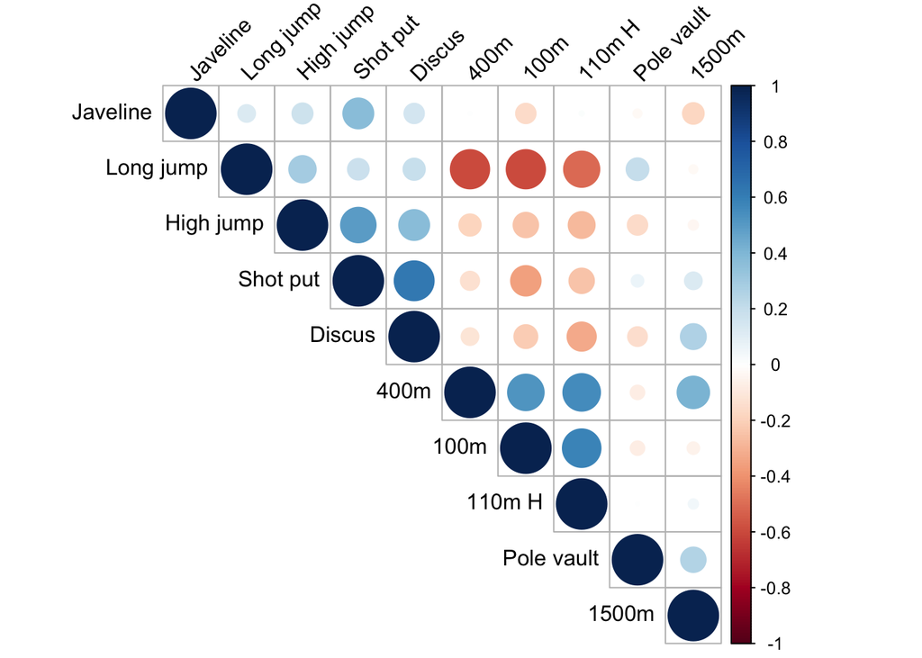

```r
corrplot(
  cor.mat,
  type  = "upper",
  order = "hclust",
  tl.col = "black",
  tl.srt = 45
)
```

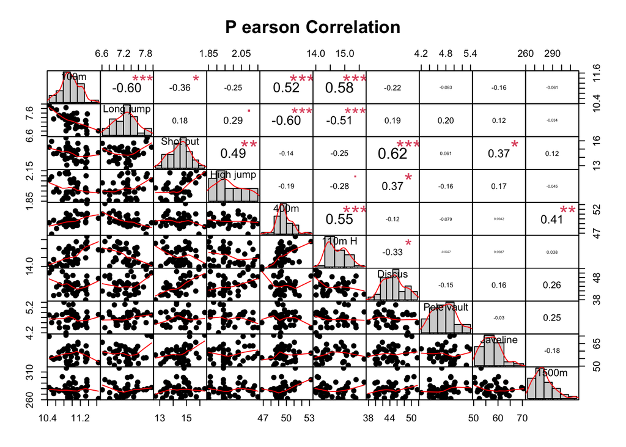

```r
chart.Correlation(decathlon[, 1:10],
                  histogram = TRUE,
                  pch       = 19)
```

**Nota**

- Correlaciones altas (en valor absoluto) entre variables sugieren **redundancia de información**, lo que hace atractivo aplicar PCA.
- `corrplot` agrupa visualmente las variables con patrones de correlación similares.

## 4.4 PCA con variables activas (primeras 10 columnas)

```r
res <- PCA(decathlon[, 1:10], ncp = 5)
summary.PCA(res)
```

```
Call:
PCA(X = decathlon[, 1:10], ncp = 5)


Eigenvalues
                      Dim.1  Dim.2  Dim.3  Dim.4  Dim.5
Variance              3.272  1.737  1.405  1.057  0.685
% of var.            32.719 17.371 14.049 10.569  6.848
Cumulative % of var. 32.719 50.090 64.140 74.708 81.556

Individuals (the 10 first)
               Dist    Dim.1    ctr   cos2    Dim.2    ctr   cos2    Dim.3
Sebrle     |  4.843 |  4.038 12.158  0.695 |  1.366  2.619  0.080 | -0.290
Clay       |  4.647 |  3.919 11.451  0.711 |  0.837  0.984  0.032 |  0.231
Karpov     |  5.006 |  4.620 15.911  0.852 |  0.040  0.002  0.000 | -0.042
Macey      |  3.434 |  2.233  3.719  0.423 |  1.042  1.524  0.092 | -1.864
Warners    |  2.979 |  2.168  3.505  0.530 | -1.803  4.565  0.366 |  0.851
Zsivoczky  |  2.566 |  0.925  0.638  0.130 |  1.169  1.918  0.207 | -1.477
Hernu      |  1.824 |  0.889  0.589  0.238 | -0.618  0.537  0.115 | -0.898
Nool       |  3.098 |  0.295  0.065  0.009 | -1.546  3.354  0.249 |  1.355
Bernard    |  2.827 |  1.906  2.709  0.455 | -0.086  0.010  0.001 | -0.757
Schwarzl   |  1.971 |  0.081  0.005  0.002 | -1.353  2.572  0.472 |  0.822
              ctr   cos2
Sebrle      0.146  0.004 |
Clay        0.093  0.002 |
Karpov      0.003  0.000 |
Macey       6.034  0.295 |
Warners     1.257  0.082 |
Zsivoczky   3.790  0.332 |
Hernu       1.401  0.242 |
Nool        3.189  0.191 |
Bernard     0.995  0.072 |
Schwarzl    1.174  0.174 |

Variables
              Dim.1    ctr   cos2    Dim.2    ctr   cos2    Dim.3    ctr   cos2
100m       | -0.775 18.344  0.600 |  0.187  2.016  0.035 | -0.184  2.420  0.034
Long jump  |  0.742 16.822  0.550 | -0.345  6.869  0.119 |  0.182  2.363  0.033
Shot put   |  0.623 11.844  0.388 |  0.598 20.607  0.358 | -0.023  0.039  0.001
High jump  |  0.572  9.998  0.327 |  0.350  7.064  0.123 | -0.260  4.794  0.067
400m       | -0.680 14.116  0.462 |  0.569 18.666  0.324 |  0.131  1.230  0.017
110m H     | -0.746 17.020  0.557 |  0.229  3.013  0.052 | -0.093  0.611  0.009
Discus     |  0.552  9.328  0.305 |  0.606 21.162  0.368 |  0.043  0.131  0.002
Pole vault |  0.050  0.077  0.003 | -0.180  1.873  0.033 |  0.692 34.061  0.479
Javeline   |  0.277  2.347  0.077 |  0.317  5.784  0.100 | -0.390 10.807  0.152
1500m      | -0.058  0.103  0.003 |  0.474 12.946  0.225 |  0.782 43.543  0.612

100m       |
Long jump  |
Shot put   |
High jump  |
400m       |
110m H     |
Discus     |
Pole vault |
Javeline   |
1500m      |
```

```r
print(res)
```

```
**Results for the Principal Component Analysis (PCA)**
The analysis was performed on 41 individuals, described by 10 variables
*The results are available in the following objects:

   name               description
1  "$eig"             "eigenvalues"
2  "$var"             "results for the variables"
3  "$var$coord"       "coord. for the variables"
4  "$var$cor"         "correlations variables - dimensions"
5  "$var$cos2"        "cos2 for the variables"
6  "$var$contrib"     "contributions of the variables"
7  "$ind"             "results for the individuals"
8  "$ind$coord"       "coord. for the individuals"
9  "$ind$cos2"        "cos2 for the individuals"
10 "$ind$contrib"     "contributions of the individuals"
11 "$call"            "summary statistics"
12 "$call$centre"     "mean of the variables"
13 "$call$ecart.type" "standard error of the variables"
14 "$call$row.w"      "weights for the individuals"
15 "$call$col.w"      "weights for the variables"
```

Aquí usamos sólo las **variables activas** (sin incluir todavía variables suplementarias).

### 4.4.1 Adecuación del análisis factorial: Bartlett y KMO

```r
bartlett.test(decathlon[, 1:10])
```

```
    Bartlett test of homogeneity of variances

data:  decathlon[, 1:10]
Bartlett's K-squared = 1268.8, df = 9, p-value < 2.2e-16
```

```r
KMO(decathlon[, 1:10])
```

```
Kaiser-Meyer-Olkin factor adequacy
Call: KMO(r = decathlon[, 1:10])
Overall MSA =  0.6
MSA for each item =
      100m  Long jump   Shot put  High jump       400m     110m H     Discus
      0.69       0.72       0.57       0.70       0.61       0.83       0.54
Pole vault   Javeline      1500m
      0.24       0.44       0.29
```

**Nota**

## 4.5 PCA con variables suplementarias

Supongamos que las columnas 11 y 12 son **cuantitativas suplementarias** (no influyen en la construcción de las componentes) y la 13 es una **cualitativa suplementaria** (por ejemplo, tipo de competición).

```r
res <- PCA(
  decathlon,
  ncp        = 5,
  quanti.sup = 11:12,
  quali.sup  = 13
)

summary(res, nbelements = Inf)
```

```
Call:
PCA(X = decathlon, ncp = 5, quanti.sup = 11:12, quali.sup = 13)


Eigenvalues
                      Dim.1  Dim.2  Dim.3  Dim.4  Dim.5
Variance              3.272  1.737  1.405  1.057  0.685
% of var.            32.719 17.371 14.049 10.569  6.848
Cumulative % of var. 32.719 50.090 64.140 74.708 81.556

Individuals
                Dist    Dim.1    ctr   cos2    Dim.2    ctr   cos2    Dim.3
Sebrle      |  4.843 |  4.038 12.158  0.695 |  1.366  2.619  0.080 | -0.290
Clay        |  4.647 |  3.919 11.451  0.711 |  0.837  0.984  0.032 |  0.231
Karpov      |  5.006 |  4.620 15.911  0.852 |  0.040  0.002  0.000 | -0.042
Macey       |  3.434 |  2.233  3.719  0.423 |  1.042  1.524  0.092 | -1.864
Warners     |  2.979 |  2.168  3.505  0.530 | -1.803  4.565  0.366 |  0.851
Zsivoczky   |  2.566 |  0.925  0.638  0.130 |  1.169  1.918  0.207 | -1.477
Hernu       |  1.824 |  0.889  0.589  0.238 | -0.618  0.537  0.115 | -0.898
Nool        |  3.098 |  0.295  0.065  0.009 | -1.546  3.354  0.249 |  1.355
Bernard     |  2.827 |  1.906  2.709  0.455 | -0.086  0.010  0.001 | -0.757
Schwarzl    |  1.971 |  0.081  0.005  0.002 | -1.353  2.572  0.472 |  0.822
Pogorelov   |  2.383 |  0.540  0.217  0.051 |  0.771  0.834  0.105 |  1.348
Schoenbeck  |  1.797 |  0.114  0.010  0.004 | -0.040  0.002  0.000 |  0.740
Barras      |  2.224 |  0.002  0.000  0.000 |  0.360  0.182  0.026 | -1.570
Smith       |  3.536 |  0.870  0.565  0.061 |  1.059  1.576  0.090 | -1.643
Averyanov   |  2.521 |  0.349  0.091  0.019 | -1.559  3.411  0.382 |  0.283
Ojaniemi    |  2.338 |  0.380  0.108  0.026 | -0.772  0.838  0.109 | -0.371
Smirnov     |  2.021 | -0.485  0.175  0.057 | -1.061  1.580  0.275 | -1.228
Qi          |  1.764 | -0.434  0.141  0.061 | -0.326  0.149  0.034 | -1.070
Drews       |  3.423 | -0.249  0.046  0.005 | -3.082 13.334  0.811 |  1.055
Parkhomenko |  3.486 | -1.069  0.853  0.094 |  2.093  6.152  0.361 | -1.000
Terek       |  3.282 | -0.682  0.347  0.043 |  0.536  0.403  0.027 |  2.209
Gomez       |  2.613 | -0.290  0.063  0.012 | -1.197  2.011  0.210 | -1.306
Turi        |  3.069 | -1.542  1.772  0.252 |  0.427  0.256  0.019 |  0.514
Lorenzo     |  3.510 | -2.409  4.324  0.471 | -1.583  3.518  0.203 | -1.502
Karlivans   |  2.704 | -1.994  2.965  0.544 | -0.294  0.122  0.012 | -0.343
Korkizoglou |  3.975 | -0.958  0.684  0.058 |  2.066  5.995  0.270 |  2.587
Uldal       |  2.946 | -2.562  4.894  0.757 |  0.245  0.085  0.007 | -0.419
Casarsa     |  4.921 | -2.857  6.085  0.337 |  3.798 20.252  0.596 |  0.031
```

[output cut: 77 more lines]

```
Javeline     0.152 |
1500m        0.612 |

Supplementary continuous variables
               Dim.1   cos2    Dim.2   cos2    Dim.3   cos2
Rank        | -0.671  0.450 |  0.051  0.003 | -0.058  0.003 |
Points      |  0.956  0.914 | -0.017  0.000 | -0.066  0.004 |

Supplementary categories
                Dist    Dim.1   cos2 v.test    Dim.2   cos2 v.test    Dim.3
Decastar    |  0.946 | -0.600  0.403 -1.430 | -0.038  0.002 -0.123 |  0.289
OlympicG    |  0.439 |  0.279  0.403  1.430 |  0.017  0.002  0.123 | -0.134
              cos2 v.test
Decastar     0.093  1.050 |
OlympicG     0.093 -1.050 |
```

```r
print(res)
```

```
**Results for the Principal Component Analysis (PCA)**
The analysis was performed on 41 individuals, described by 13 variables
*The results are available in the following objects:

   name
1  "$eig"
2  "$var"
3  "$var$coord"
4  "$var$cor"
5  "$var$cos2"
6  "$var$contrib"
7  "$ind"
8  "$ind$coord"
9  "$ind$cos2"
10 "$ind$contrib"
```

[output cut: 33 more lines]

### 4.5.1 Valores propios y varianza explicada

```r
eigenvalues <- res$eig
eigenvalues[, 1:3]
```

```
       eigenvalue percentage of variance cumulative percentage of variance
comp 1  3.2719055              32.719055                          32.71906
comp 2  1.7371310              17.371310                          50.09037
comp 3  1.4049167              14.049167                          64.13953
comp 4  1.0568504              10.568504                          74.70804
comp 5  0.6847735               6.847735                          81.55577
```

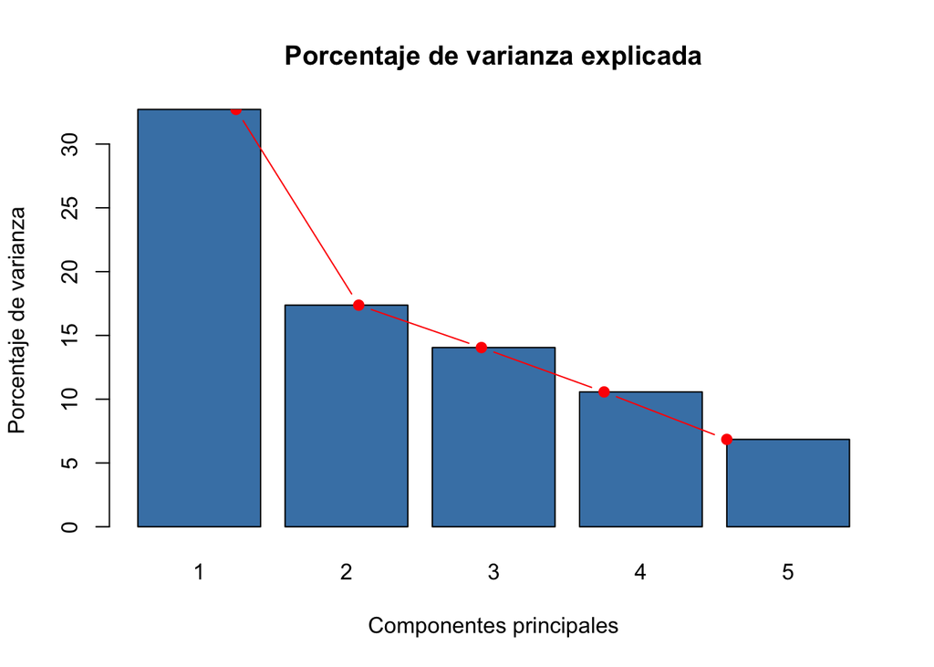

```r
barplot(
  eigenvalues[, 2],
  names.arg = 1:nrow(eigenvalues),
  main = "Porcentaje de varianza explicada",
  xlab = "Componentes principales",
  ylab = "Porcentaje de varianza",
  col  = "steelblue"
)

lines(x = 1:nrow(eigenvalues),
      y = eigenvalues[, 2],
      type = "b",
      pch  = 19,
      col  = "red")
```

**Tip**

- La primera columna son los **valores propios** (lambda_i).
- La segunda columna es el **porcentaje de varianza explicada**.
- Fíjate cuántas componentes necesitas para explicar, por ejemplo, el **70%–80%** de la varianza.

## 4.6 Descripción de las dimensiones

`dimdesc` ayuda a interpretar cada componente, relacionándola con las variables originales:

```r
dimdesc(res)
```

```
$Dim.1

Link between the variable and the continuous variables (R-square)
=================================================================================
          correlation      p.value  n
Points      0.9561543 2.099191e-22 41
Long jump   0.7418997 2.849886e-08 41
Shot put    0.6225026 1.388321e-05 41
High jump   0.5719453 9.362285e-05 41
Discus      0.5524665 1.802220e-04 41
Rank       -0.6705104 1.616348e-06 41
400m       -0.6796099 1.028175e-06 41
110m H     -0.7462453 2.136962e-08 41
100m       -0.7747198 2.778467e-09 41

$Dim.2

Link between the variable and the continuous variables (R-square)
=================================================================================
          correlation      p.value  n
Discus      0.6063134 2.650745e-05 41
Shot put    0.5983033 3.603567e-05 41
400m        0.5694378 1.020941e-04 41
1500m       0.4742238 1.734405e-03 41
High jump   0.3502936 2.475025e-02 41
Javeline    0.3169891 4.344974e-02 41
Long jump  -0.3454213 2.696969e-02 41

$Dim.3

Link between the variable and the continuous variables (R-square)
=================================================================================
           correlation      p.value  n
1500m        0.7821428 1.554450e-09 41
Pole vault   0.6917567 5.480172e-07 41
Javeline    -0.3896554 1.179331e-02 41
```

```r
dimdesc(res, axes = c(1, 2, 3, 4, 5))
```

```
$Dim.1

Link between the variable and the continuous variables (R-square)
=================================================================================
          correlation      p.value  n
Points      0.9561543 2.099191e-22 41
Long jump   0.7418997 2.849886e-08 41
Shot put    0.6225026 1.388321e-05 41
High jump   0.5719453 9.362285e-05 41
Discus      0.5524665 1.802220e-04 41
Rank       -0.6705104 1.616348e-06 41
400m       -0.6796099 1.028175e-06 41
110m H     -0.7462453 2.136962e-08 41
100m       -0.7747198 2.778467e-09 41

$Dim.2

Link between the variable and the continuous variables (R-square)
=================================================================================
          correlation      p.value  n
Discus      0.6063134 2.650745e-05 41
Shot put    0.5983033 3.603567e-05 41
400m        0.5694378 1.020941e-04 41
1500m       0.4742238 1.734405e-03 41
High jump   0.3502936 2.475025e-02 41
Javeline    0.3169891 4.344974e-02 41
Long jump  -0.3454213 2.696969e-02 41

$Dim.3

Link between the variable and the continuous variables (R-square)
=================================================================================
           correlation      p.value  n
1500m        0.7821428 1.554450e-09 41
Pole vault   0.6917567 5.480172e-07 41
Javeline    -0.3896554 1.179331e-02 41

$Dim.4

Link between the variable and the continuous variables (R-square)
```

[output cut: 9 more lines]

```
           correlation      p.value  n
High jump    0.5554396 0.0001635051 41
Pole vault   0.3299593 0.0351316637 41
Rank        -0.3500257 0.0248682140 41

Link between the variable and the categorical variable (1-way anova)
=============================================
       R2   p.value
0.1092271 0.0348183

Link between variable and the categories of the categorical variables
================================================================
                       Estimate   p.value
Competition=Decastar  0.2938609 0.0348183
Competition=OlympicG -0.2938609 0.0348183
```

```r
dimdesc(res, proba = 0.2)
```

```
$Dim.1

Link between the variable and the continuous variables (R-square)
=================================================================================
          correlation      p.value  n
Points      0.9561543 2.099191e-22 41
Long jump   0.7418997 2.849886e-08 41
Shot put    0.6225026 1.388321e-05 41
High jump   0.5719453 9.362285e-05 41
Discus      0.5524665 1.802220e-04 41
Javeline    0.2771108 7.942460e-02 41
Rank       -0.6705104 1.616348e-06 41
400m       -0.6796099 1.028175e-06 41
110m H     -0.7462453 2.136962e-08 41
100m       -0.7747198 2.778467e-09 41

Link between the variable and the categorical variable (1-way anova)
=============================================
        R2    p.value
0.05110487 0.15525150

Link between variable and the categories of the categorical variables
================================================================
                       Estimate   p.value
Competition=OlympicG  0.4393744 0.1552515
Competition=Decastar -0.4393744 0.1552515

$Dim.2

Link between the variable and the continuous variables (R-square)
=================================================================================
          correlation      p.value  n
Discus      0.6063134 2.650745e-05 41
Shot put    0.5983033 3.603567e-05 41
400m        0.5694378 1.020941e-04 41
1500m       0.4742238 1.734405e-03 41
High jump   0.3502936 2.475025e-02 41
Javeline    0.3169891 4.344974e-02 41
110m H      0.2287933 1.501925e-01 41
Long jump  -0.3454213 2.696969e-02 41

$Dim.3

Link between the variable and the continuous variables (R-square)
=================================================================================
           correlation      p.value  n
1500m        0.7821428 1.554450e-09 41
Pole vault   0.6917567 5.480172e-07 41
High jump   -0.2595119 1.013160e-01 41
Javeline    -0.3896554 1.179331e-02 41
```

## 4.7 Coordenadas, cos2 y contribuciones de las variables

```r
# Coordenadas de las variables
res$var$coord
```

```
                 Dim.1      Dim.2       Dim.3       Dim.4       Dim.5
100m       -0.77471983  0.1871420 -0.18440714 -0.03781826  0.30219639
Long jump   0.74189974 -0.3454213  0.18221105  0.10178564  0.03667805
Shot put    0.62250255  0.5983033 -0.02337844  0.19059161  0.11115082
High jump   0.57194530  0.3502936 -0.25951193 -0.13559420  0.55543957
400m       -0.67960994  0.5694378  0.13146970  0.02930198 -0.08769157
110m H     -0.74624532  0.2287933 -0.09263738  0.29083103  0.16432095
Discus      0.55246652  0.6063134  0.04295225 -0.25967143 -0.10482712
Pole vault  0.05034151 -0.1803569  0.69175665  0.55153397  0.32995932
Javeline    0.27711085  0.3169891 -0.38965541  0.71227728 -0.30512892
1500m      -0.05807706  0.4742238  0.78214280 -0.16108904 -0.15356189
```

```r
# Calidad de representación (cos2)
res$var$cos2
```

```
                 Dim.1      Dim.2        Dim.3        Dim.4       Dim.5
100m       0.600190812 0.03502213 0.0340059930 0.0014302206 0.091322660
Long jump  0.550415232 0.11931587 0.0332008675 0.0103603165 0.001345279
Shot put   0.387509426 0.35796686 0.0005465513 0.0363251605 0.012354505
High jump  0.327121422 0.12270561 0.0673464410 0.0183857880 0.308513117
400m       0.461869674 0.32425938 0.0172842817 0.0008586058 0.007689811
110m H     0.556882084 0.05234639 0.0085816841 0.0845826853 0.027001375
Discus     0.305219255 0.36761593 0.0018448960 0.0674292539 0.010988725
Pole vault 0.002534268 0.03252860 0.4785272696 0.3041897208 0.108873151
Javeline   0.076790421 0.10048206 0.1518313365 0.5073389244 0.093103658
1500m      0.003372945 0.22488818 0.6117473613 0.0259496775 0.023581254
```

```r
# Contribuciones (en %)
res$var$contrib
```

```
                 Dim.1     Dim.2       Dim.3       Dim.4     Dim.5
100m       18.34376957  2.016090  2.42049891  0.13532858 13.336184
Long jump  16.82246707  6.868559  2.36319121  0.98030118  0.196456
Shot put   11.84353954 20.606785  0.03890276  3.43711486  1.804174
High jump   9.99788710  7.063694  4.79362526  1.73967752 45.053306
400m       14.11622887 18.666374  1.23027094  0.08124195  1.122971
110m H     17.02011495  3.013382  0.61083225  8.00327927  3.943110
Discus      9.32848615 21.162245  0.13131711  6.38020830  1.604724
Pole vault  0.07745541  1.872547 34.06090024 28.78266727 15.899147
Javeline    2.34696326  5.784369 10.80714169 48.00480246 13.596270
1500m       0.10308808 12.945954 43.54331962  2.45537861  3.443657
```

### 4.7.1 Gráfico de variables

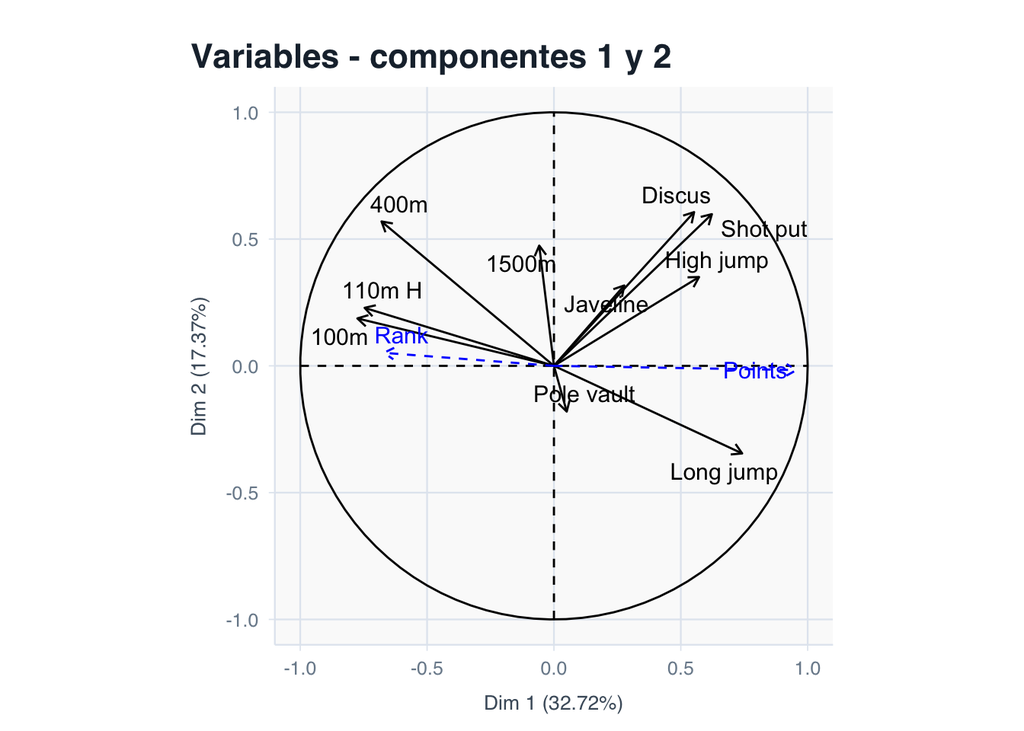

```r
plot(res, choix = "var", title = "Variables - componentes 1 y 2", axes = 1:2)
```

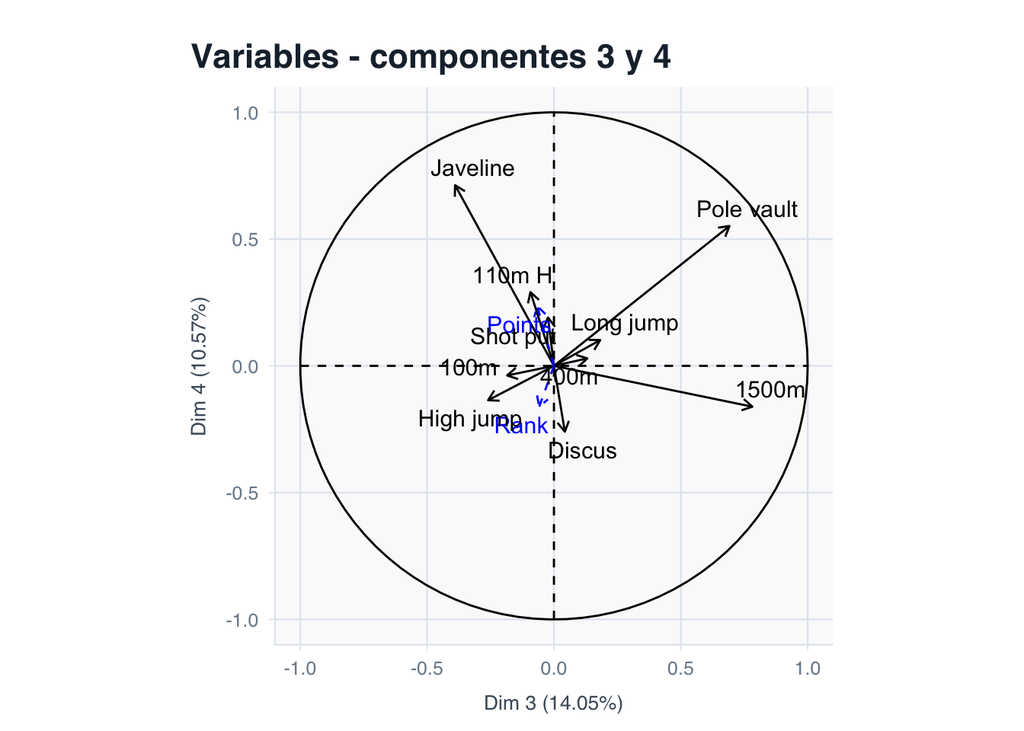

```r
plot(res, choix = "var", title = "Variables - componentes 3 y 4", axes = 3:4)
```

**Nota**

- Las variables cercanas unas a otras están **positivamente correlacionadas**.
- Variables opuestas en un mismo eje tienen correlación **negativa**.
- La distancia al origen indica la **importancia** en esas componentes (cos2 alto).

## 4.8 Individuos: coordenadas, cos2 y contribuciones

```r
# Coordenadas de los individuos
head(res$ind$coord)
```

```
              Dim.1       Dim.2      Dim.3      Dim.4      Dim.5
Sebrle    4.0384485  1.36582606 -0.2899565  1.9411341  0.3769545
Clay      3.9193652  0.83696136  0.2311753  1.4939721 -1.0376085
Karpov    4.6199873  0.03999523 -0.0415858 -1.3135257  0.1877295
Macey     2.2334606  1.04176620 -1.8643620 -0.7432135  0.9772701
Warners   2.1683964 -1.80320025  0.8510173 -0.2845996 -0.1513946
Zsivoczky 0.9251322  1.16865180 -1.4774803  0.8075947  0.8729726
```

```r
# Calidad de representación
head(res$ind$cos2)
```

```
              Dim.1        Dim.2        Dim.3       Dim.4       Dim.5
Sebrle    0.6954102 7.954314e-02 0.0035849052 0.160665653 0.006058846
Clay      0.7112052 3.243204e-02 0.0024742661 0.103335239 0.049846023
Karpov    0.8517553 6.383365e-05 0.0000690118 0.068851025 0.001406366
Macey     0.4230486 9.203950e-02 0.2947774222 0.046844751 0.080995884
Warners   0.5299437 3.664716e-01 0.0816261239 0.009128951 0.002583291
Zsivoczky 0.1299979 2.074432e-01 0.3315677581 0.099063996 0.115752425
```

```r
# Contribuciones
head(res$ind$contrib)
```

```
               Dim.1       Dim.2       Dim.3     Dim.4      Dim.5
Sebrle    12.1575058 2.619234357 0.145959136 8.6958838 0.50611259
Clay      11.4510904 0.983545343 0.092778749 5.1509536 3.83474272
Karpov    15.9109806 0.002245949 0.003002311 3.9818030 0.12552619
Macey      3.7185358 1.523786399 6.034288443 1.2747642 3.40171873
Warners    3.5050382 4.565322740 1.257310032 0.1869266 0.08163758
Zsivoczky  0.6380034 1.917581489 3.789736079 1.5051840 2.71437829
```

### 4.8.1 Gráfico de individuos

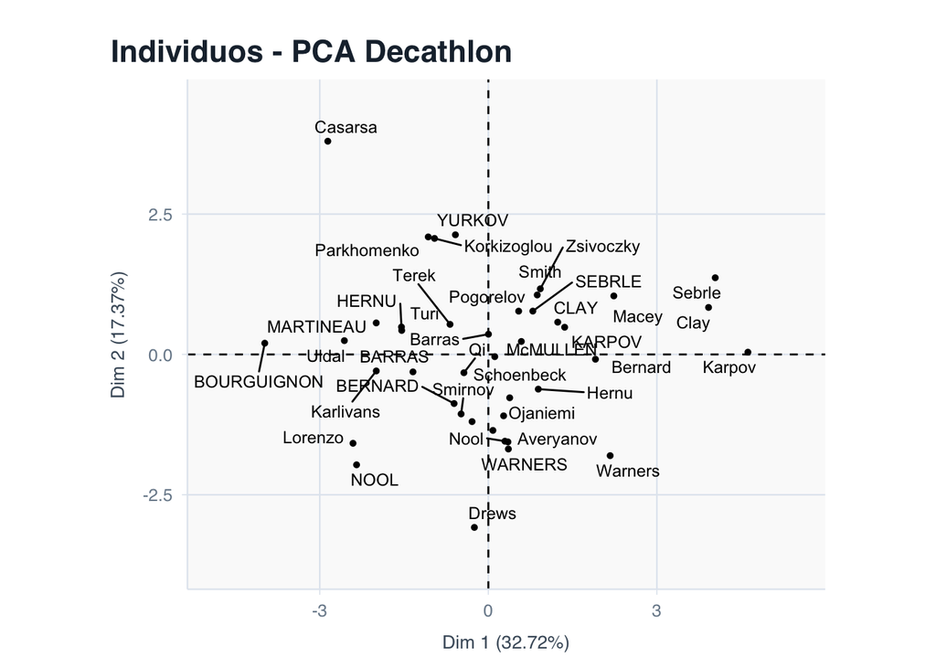

```r
# Sin mostrar las variables cualitativas
plot(res, cex = 0.8, invisible = "quali",
     title = "Individuos - PCA Decathlon")
```

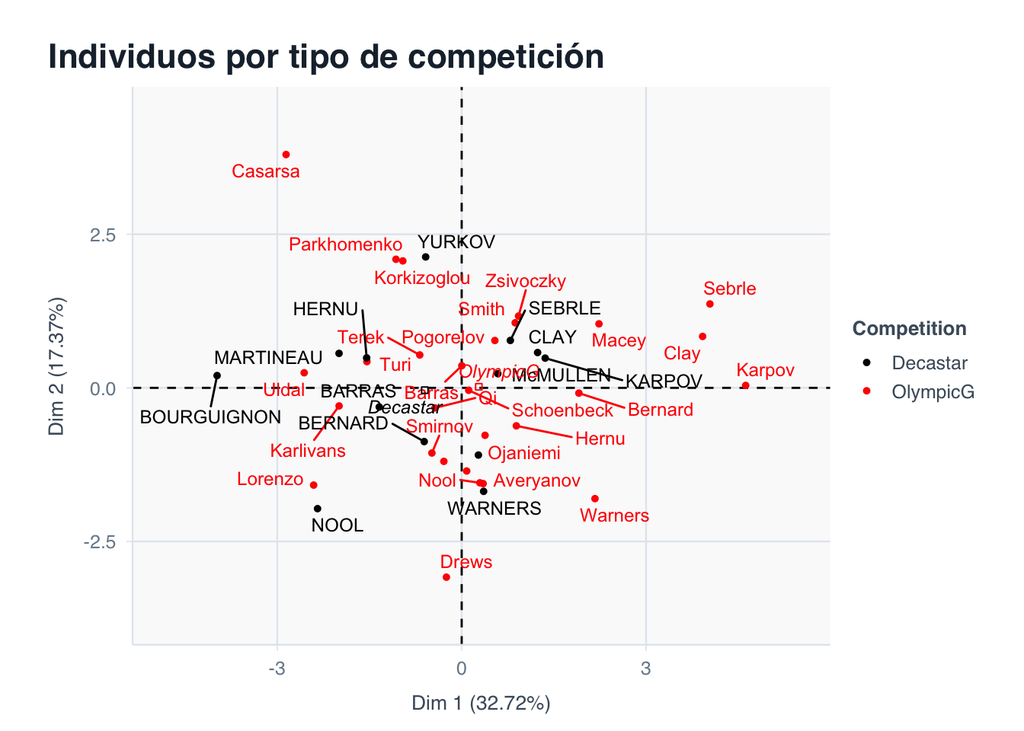

```r
# Coloreando por competición (columna 13)
plot(res, cex = 0.8, habillage = 13,
     title = "Individuos por tipo de competición")
```

### 4.8.2 Elipses de confianza por categoría

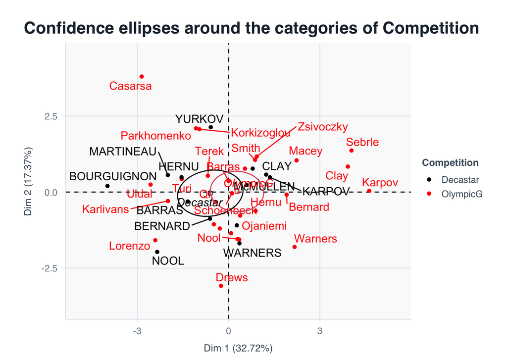

```r
plotellipses(res)
```

### 4.8.3 Otras vistas y selección de individuos

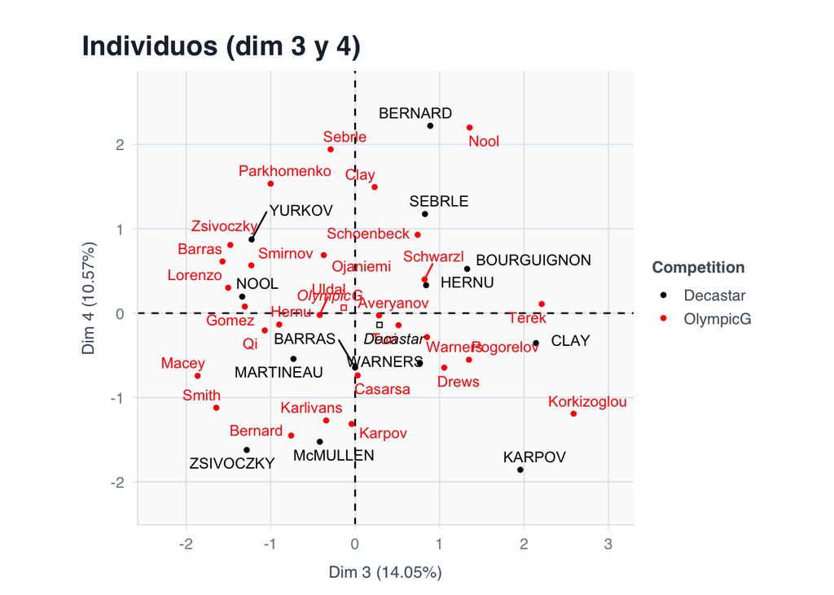

```r
# Dimensiones 3 y 4
plot(res, choix = "ind", cex = 0.8, habillage = 13,
     title = "Individuos (dim 3 y 4)", axes = 3:4)
```

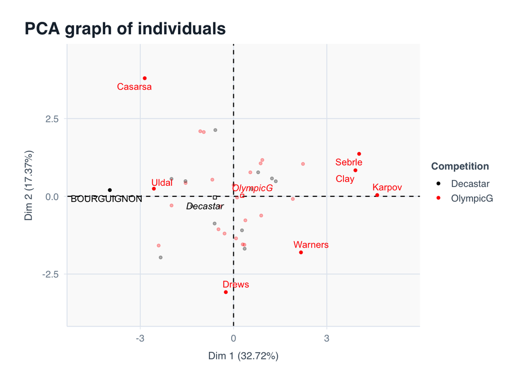

```r
# Seleccionar individuos bien representados
plot(res, cex = 0.8, habillage = 13, select = "cos2 0.7")
```

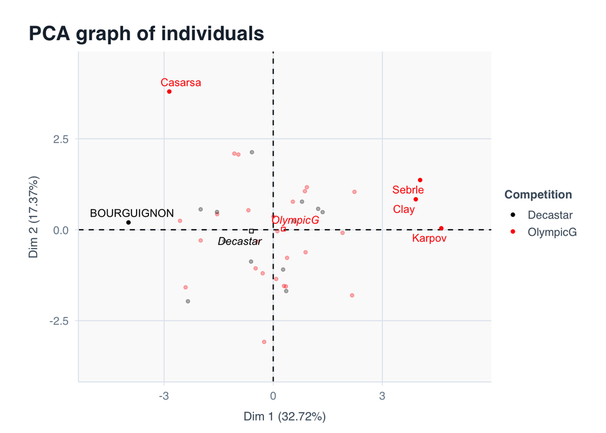

```r
# Seleccionar individuos con mayor contribución
plot(res, cex = 0.8, habillage = 13, select = "contrib 5")
```

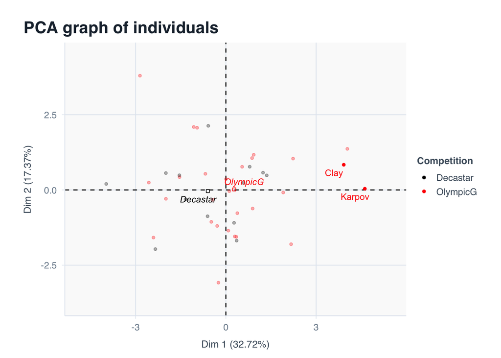

```r
# Seleccionar individuos específicos (por nombre)
plot(res, cex = 0.8, habillage = 13,
     select = c("Clay", "Karpov"))
```

### 4.8.4 Selección de variables importantes

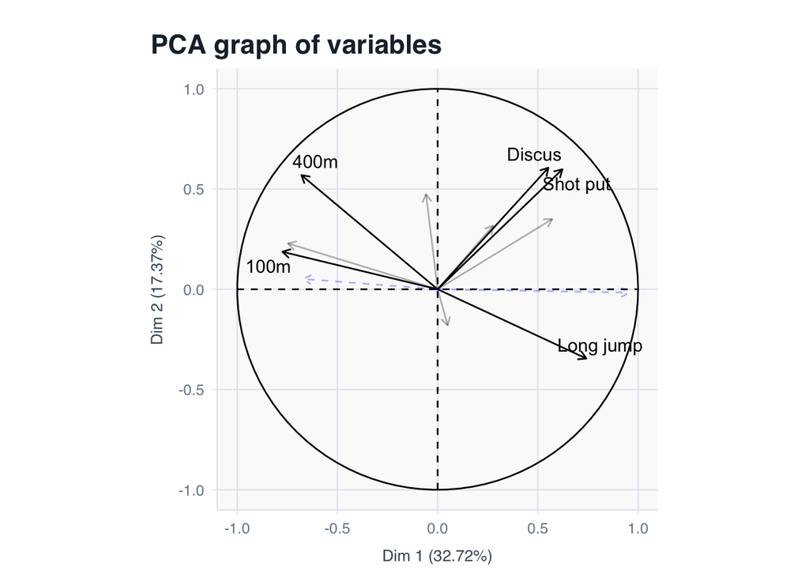

```r
plot(res, choix = "var", select = "contrib 5")
```

### 4.8.5 Gráfico con varios argumentos

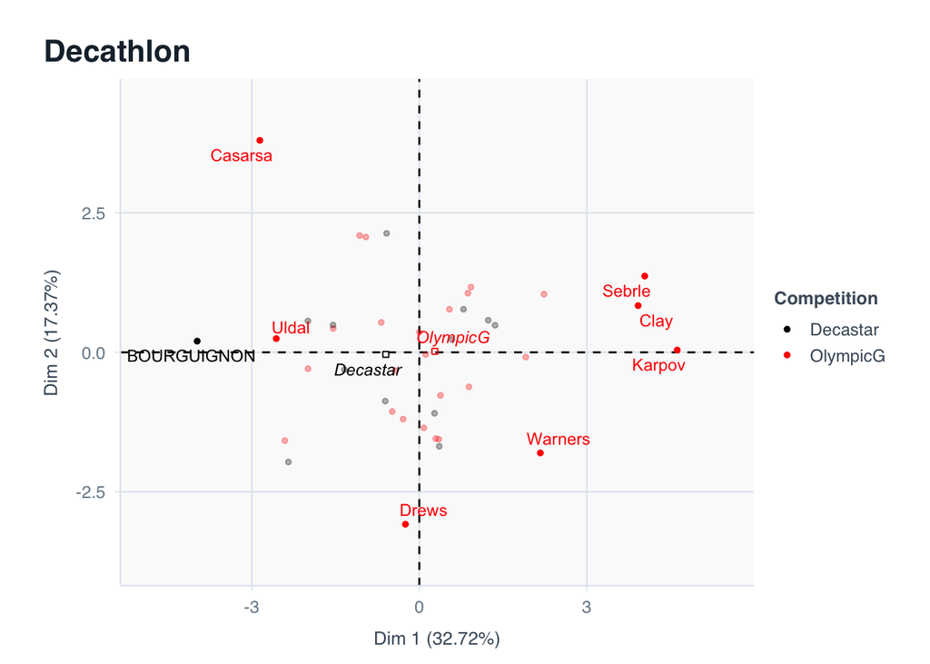

```r
plot(
  res,
  cex        = 0.8,
  habillage  = 13,
  select     = "cos2 0.7",
  title      = "Decathlon",
  cex.main   = 1.1,
  cex.axis   = 0.9,
  shadow     = TRUE,
  auto       = "y"
)
```

# 5 Parte 2: PCA con datos de jugos de naranja (`orange`)

En el segundo bloque analizamos una base de datos de jugos de naranja:

- Columnas 1 a 14: **variables cuantitativas** (por ejemplo, atributos químicos/sensoriales).
- Columnas 15 y 16: **variables cualitativas suplementarias** (por ejemplo, origen, tipo de marca, etc.).

## 5.1 Importar datos de orange

```r
archivo_orange <- file.path(ruta_datos, "orange.csv")

orange <- read.table(
  archivo_orange,
  header      = TRUE,
  sep         = ";",
  dec         = ".",
  row.names   = 1,
  check.names = FALSE
)

summary(orange)
```

```
 Odour intensity Odour typicality   Pulpiness     Intensity of taste
 Min.   :2.760   Min.   :2.530    Min.   :1.660   Min.   :3.120
 1st Qu.:2.775   1st Qu.:2.625    1st Qu.:1.722   1st Qu.:3.265
 Median :2.825   Median :2.775    Median :2.625   Median :3.410
 Mean   :2.907   Mean   :2.762    Mean   :2.710   Mean   :3.362
 3rd Qu.:3.010   3rd Qu.:2.865    3rd Qu.:3.603   3rd Qu.:3.458
 Max.   :3.200   Max.   :3.020    Max.   :4.000   Max.   :3.540
    Acidity        Bitterness      Sweetness        Glucose
 Min.   :2.330   Min.   :1.760   Min.   :2.600   Min.   :17.33
 1st Qu.:2.453   1st Qu.:1.998   1st Qu.:2.825   1st Qu.:22.94
 Median :2.800   Median :2.320   Median :3.110   Median :24.48
 Mean   :2.802   Mean   :2.328   Mean   :3.057   Mean   :24.76
 3rd Qu.:3.125   3rd Qu.:2.612   3rd Qu.:3.335   3rd Qu.:26.70
 Max.   :3.310   Max.   :2.970   Max.   :3.380   Max.   :32.42
    Fructose       Saccharose    Sweetening power       pH
 Min.   :20.00   Min.   :22.92   Min.   : 82.55   Min.   :3.590
 1st Qu.:25.40   1st Qu.:37.07   1st Qu.: 90.14   1st Qu.:3.620
 Median :26.50   Median :41.55   Median : 92.79   Median :3.750
 Mean   :27.06   Mean   :40.06   Mean   : 92.80   Mean   :3.738
 3rd Qu.:28.95   3rd Qu.:45.39   3rd Qu.: 96.10   3rd Qu.:3.842
 Max.   :34.54   Max.   :52.12   Max.   :102.22   Max.   :3.890
  Citric acid       Vitamin C     Way of preserving       Origin
 Min.   :0.6700   Min.   :27.00   Length   :6       Length   :6
 1st Qu.:0.6950   1st Qu.:33.67   N.unique :2       N.unique :2
 Median :0.7250   Median :36.80   N.blank  :0       N.blank  :0
 Mean   :0.7667   Mean   :36.04   Min.nchar:5       Min.nchar:5
 3rd Qu.:0.8150   3rd Qu.:38.88   Max.nchar:7       Max.nchar:7
 Max.   :0.9500   Max.   :43.44
```

## 5.2 PCA con variables activas (1 a 14)

```r
res <- PCA(orange[, 1:14], ncp = 3)
summary(res)
```

```
Call:
PCA(X = orange[, 1:14], ncp = 3)


Eigenvalues
                      Dim.1  Dim.2  Dim.3
Variance              8.065  2.583  1.461
% of var.            57.607 18.450 10.438
Cumulative % of var. 57.607 76.057 86.496

Individuals
                       Dist    Dim.1    ctr   cos2    Dim.2    ctr   cos2
Pampryl amb.       |  3.700 | -3.090 19.727  0.697 | -1.026  6.797  0.077 |
Tropicana amb.     |  3.885 |  2.358 11.486  0.368 | -2.825 51.491  0.529 |
Fruvita fr.        |  3.536 |  2.688 14.928  0.578 |  1.385 12.373  0.153 |
Joker amb.         |  4.300 | -3.895 31.359  0.821 | -0.127  0.104  0.001 |
Tropicana fr.      |  3.800 |  3.092 19.757  0.662 |  0.533  1.830  0.020 |
Pampryl fr.        |  3.128 | -1.152  2.743  0.136 |  2.061 27.405  0.434 |
                    Dim.3    ctr   cos2
Pampryl amb.        0.022  0.006  0.000 |
Tropicana amb.     -1.076 13.205  0.077 |
Fruvita fr.        -0.076  0.067  0.000 |
Joker amb.          1.184 15.976  0.076 |
Tropicana fr.       1.734 34.298  0.208 |
Pampryl fr.        -1.788 36.449  0.327 |

Variables (the 10 first)
                      Dim.1    ctr   cos2    Dim.2    ctr   cos2    Dim.3
Odour intensity    |  0.352  1.533  0.124 |  0.561 12.192  0.315 |  0.168
Odour typicality   |  0.938 10.898  0.879 |  0.205  1.626  0.042 |  0.185
Pulpiness          |  0.666  5.498  0.443 |  0.742 21.330  0.551 |  0.010
Intensity of taste | -0.554  3.800  0.306 |  0.453  7.954  0.205 | -0.564
Acidity            | -0.878  9.560  0.771 |  0.160  0.995  0.026 | -0.407
Bitterness         | -0.897  9.978  0.805 | -0.084  0.274  0.007 | -0.183
Sweetness          |  0.958 11.384  0.918 |  0.011  0.005  0.000 |  0.068
Glucose            | -0.786  7.652  0.617 |  0.493  9.424  0.243 |  0.280
Fructose           | -0.781  7.554  0.609 |  0.489  9.251  0.239 |  0.288
Saccharose         |  0.891  9.841  0.794 |  0.133  0.689  0.018 | -0.207
                      ctr   cos2
Odour intensity     1.936  0.028 |
Odour typicality    2.336  0.034 |
Pulpiness           0.006  0.000 |
Intensity of taste 21.785  0.318 |
Acidity            11.316  0.165 |
Bitterness          2.301  0.034 |
Sweetness           0.315  0.005 |
Glucose             5.376  0.079 |
Fructose            5.683  0.083 |
Saccharose          2.925  0.043 |
```

```r
print(res)
```

```
**Results for the Principal Component Analysis (PCA)**
The analysis was performed on 6 individuals, described by 14 variables
*The results are available in the following objects:

   name               description
1  "$eig"             "eigenvalues"
2  "$var"             "results for the variables"
3  "$var$coord"       "coord. for the variables"
4  "$var$cor"         "correlations variables - dimensions"
5  "$var$cos2"        "cos2 for the variables"
6  "$var$contrib"     "contributions of the variables"
7  "$ind"             "results for the individuals"
8  "$ind$coord"       "coord. for the individuals"
9  "$ind$cos2"        "cos2 for the individuals"
10 "$ind$contrib"     "contributions of the individuals"
11 "$call"            "summary statistics"
12 "$call$centre"     "mean of the variables"
13 "$call$ecart.type" "standard error of the variables"
14 "$call$row.w"      "weights for the individuals"
15 "$call$col.w"      "weights for the variables"
```

## 5.3 PCA con variables suplementarias

Consideramos ahora que las columnas 15 y 16 son cualitativas suplementarias (por ejemplo, **origen** del jugo).

```r
res2 <- PCA(orange, quali.sup = 15:16)
summary(res2, nbelements = Inf)
```

```
Call:
PCA(X = orange, quali.sup = 15:16)


Eigenvalues
                       Dim.1   Dim.2   Dim.3   Dim.4   Dim.5
Variance               8.065   2.583   1.461   1.011   0.880
% of var.             57.607  18.450  10.438   7.220   6.285
Cumulative % of var.  57.607  76.057  86.496  93.715 100.000

Individuals
                       Dist    Dim.1    ctr   cos2    Dim.2    ctr   cos2
Pampryl amb.       |  3.700 | -3.090 19.727  0.697 | -1.026  6.797  0.077 |
Tropicana amb.     |  3.885 |  2.358 11.486  0.368 | -2.825 51.491  0.529 |
Fruvita fr.        |  3.536 |  2.688 14.928  0.578 |  1.385 12.373  0.153 |
Joker amb.         |  4.300 | -3.895 31.359  0.821 | -0.127  0.104  0.001 |
Tropicana fr.      |  3.800 |  3.092 19.757  0.662 |  0.533  1.830  0.020 |
Pampryl fr.        |  3.128 | -1.152  2.743  0.136 |  2.061 27.405  0.434 |
                    Dim.3    ctr   cos2
Pampryl amb.        0.022  0.006  0.000 |
Tropicana amb.     -1.076 13.205  0.077 |
Fruvita fr.        -0.076  0.067  0.000 |
Joker amb.          1.184 15.976  0.076 |
Tropicana fr.       1.734 34.298  0.208 |
Pampryl fr.        -1.788 36.449  0.327 |

Variables
                      Dim.1    ctr   cos2    Dim.2    ctr   cos2    Dim.3
Odour intensity    |  0.352  1.533  0.124 |  0.561 12.192  0.315 |  0.168
Odour typicality   |  0.938 10.898  0.879 |  0.205  1.626  0.042 |  0.185
Pulpiness          |  0.666  5.498  0.443 |  0.742 21.330  0.551 |  0.010
Intensity of taste | -0.554  3.800  0.306 |  0.453  7.954  0.205 | -0.564
Acidity            | -0.878  9.560  0.771 |  0.160  0.995  0.026 | -0.407
Bitterness         | -0.897  9.978  0.805 | -0.084  0.274  0.007 | -0.183
Sweetness          |  0.958 11.384  0.918 |  0.011  0.005  0.000 |  0.068
Glucose            | -0.786  7.652  0.617 |  0.493  9.424  0.243 |  0.280
Fructose           | -0.781  7.554  0.609 |  0.489  9.251  0.239 |  0.288
Saccharose         |  0.891  9.841  0.794 |  0.133  0.689  0.018 | -0.207
Sweetening power   |  0.194  0.467  0.038 |  0.915 32.396  0.837 |  0.107
pH                 |  0.964 11.525  0.930 | -0.156  0.941  0.024 | -0.107
```

[output cut: 14 more lines]

```
pH                  0.776  0.011 |
Citric acid        10.368  0.152 |
Vitamin C          34.099  0.498 |

Supplementary categories
                       Dist    Dim.1   cos2 v.test    Dim.2   cos2 v.test
Ambient            |  2.040 | -1.543  0.572 -1.215 | -1.326  0.423 -1.845 |
Fresh              |  2.040 |  1.543  0.572  1.215 |  1.326  0.423  1.845 |
Florida            |  2.741 |  2.712  0.979  2.136 | -0.303  0.012 -0.421 |
Other              |  2.741 | -2.712  0.979 -2.136 |  0.303  0.012  0.421 |
                    Dim.3   cos2 v.test
Ambient             0.043  0.000  0.080 |
Fresh              -0.043  0.000 -0.080 |
Florida             0.194  0.005  0.359 |
Other              -0.194  0.005 -0.359 |
```

## 5.4 Valores propios y varianza explicada

```r
eigenvalues <- res$eig
eigenvalues[, 1:3]
```

```
       eigenvalue percentage of variance cumulative percentage of variance
comp 1   8.064950               57.60679                          57.60679
comp 2   2.583034               18.45024                          76.05703
comp 3   1.461389               10.43849                          86.49552
```

## 5.5 Test de Bartlett y KMO para orange

```r
bartlett.test(orange[, 1:14])
```

```
    Bartlett test of homogeneity of variances

data:  orange[, 1:14]
Bartlett's K-squared = 210.49, df = 13, p-value < 2.2e-16
```

```r
KMO(orange[, 1:14])
```

[output not shown]

```
Kaiser-Meyer-Olkin factor adequacy
Call: KMO(r = orange[, 1:14])
Overall MSA =  0.5
MSA for each item =
   Odour intensity   Odour typicality          Pulpiness Intensity of taste
               0.5                0.5                0.5                0.5
           Acidity         Bitterness          Sweetness            Glucose
               0.5                0.5                0.5                0.5
          Fructose         Saccharose   Sweetening power                 pH
               0.5                0.5                0.5                0.5
       Citric acid          Vitamin C
               0.5                0.5
```

## 5.6 Descripción de las dimensiones

```r
dimdesc(res)
```

```
$Dim.1

Link between the variable and the continuous variables (R-square)
=================================================================================
                 correlation     p.value n
pH                 0.9641128 0.001908728 6
Sweetness          0.9581672 0.002588371 6
Odour typicality   0.9375068 0.005736073 6
Saccharose         0.8908878 0.017208699 6
Acidity           -0.8780844 0.021389085 6
Bitterness        -0.8970717 0.015346133 6
Citric acid       -0.9057713 0.012900241 6

$Dim.2

Link between the variable and the continuous variables (R-square)
=================================================================================
                 correlation   p.value n
Sweetening power   0.9147625 0.0105885 6

$Dim.3
```

```r
dimdesc(res, axes = c(1, 2))
```

```
$Dim.1

Link between the variable and the continuous variables (R-square)
=================================================================================
                 correlation     p.value n
pH                 0.9641128 0.001908728 6
Sweetness          0.9581672 0.002588371 6
Odour typicality   0.9375068 0.005736073 6
Saccharose         0.8908878 0.017208699 6
Acidity           -0.8780844 0.021389085 6
Bitterness        -0.8970717 0.015346133 6
Citric acid       -0.9057713 0.012900241 6

$Dim.2

Link between the variable and the continuous variables (R-square)
=================================================================================
                 correlation   p.value n
Sweetening power   0.9147625 0.0105885 6
```

```r
dimdesc(res, proba = 0.2)
```

```
$Dim.1

Link between the variable and the continuous variables (R-square)
=================================================================================
                 correlation     p.value n
pH                 0.9641128 0.001908728 6
Sweetness          0.9581672 0.002588371 6
Odour typicality   0.9375068 0.005736073 6
Saccharose         0.8908878 0.017208699 6
Pulpiness          0.6659126 0.148777121 6
Fructose          -0.7805085 0.066977593 6
Glucose           -0.7856011 0.064022682 6
Acidity           -0.8780844 0.021389085 6
Bitterness        -0.8970717 0.015346133 6
Citric acid       -0.9057713 0.012900241 6

$Dim.2

Link between the variable and the continuous variables (R-square)
=================================================================================
                 correlation    p.value n
Sweetening power   0.9147625 0.01058850 6
Pulpiness          0.7422675 0.09107899 6

$Dim.3

Link between the variable and the continuous variables (R-square)
=================================================================================
          correlation   p.value n
Vitamin C   0.7059171 0.1170103 6
```

## 5.7 Gráficos de individuos y variables

### 5.7.1 Individuos

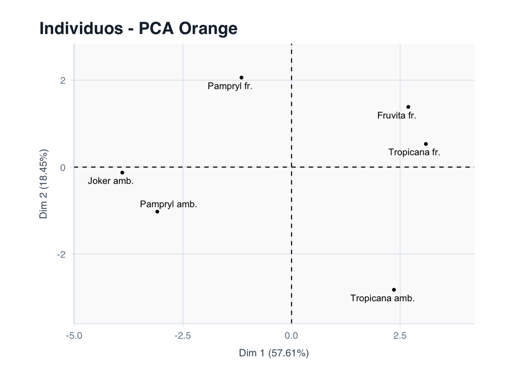

```r
# Individuos sin variables cualitativas
plot(res, cex = 0.8, invisible = "quali",
     title = "Individuos - PCA Orange")
```

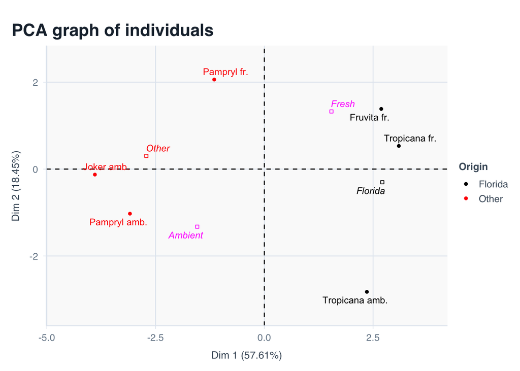

```r
# Coloreados según variable de origen (si existe en el dataset)
plot(res2, cex = 0.8, habillage = "Origin")
```

### 5.7.2 Elipses de confianza

```r
plotellipses(res)
```

[output not shown]

### 5.7.3 Selección de individuos y variables

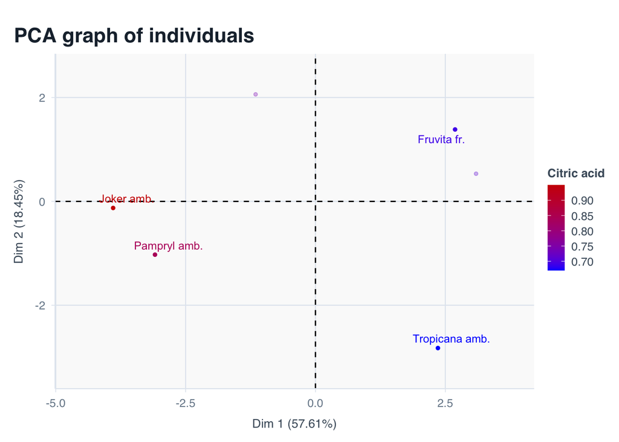

```r
# Individuos bien representados
plot(res, cex = 0.8, habillage = 13, select = "cos2 0.7")
```

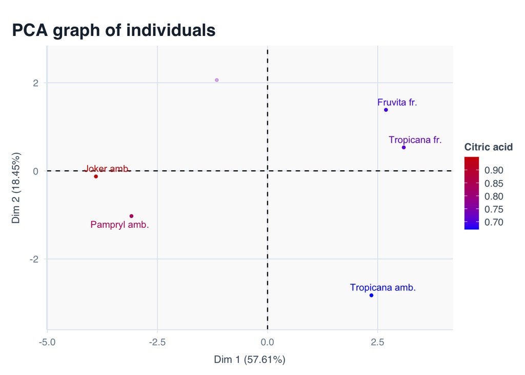

```r
# Individuos con mayor contribución
plot(res, cex = 0.8, habillage = 13, select = "contrib 5")
```

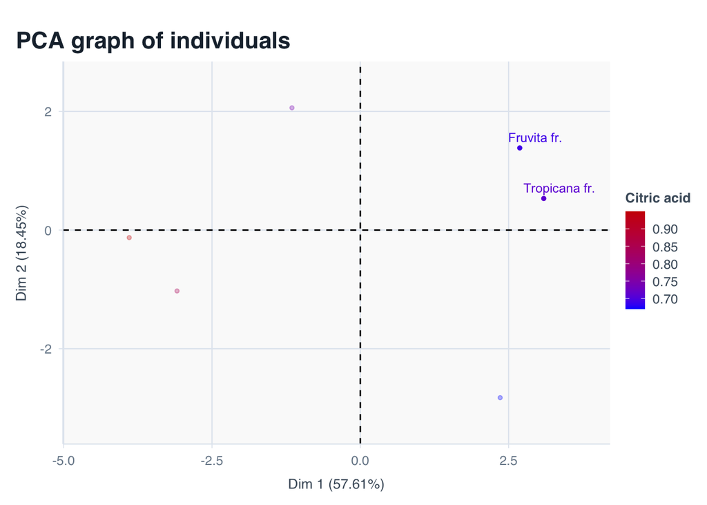

```r
# Individuos específicos (ejemplo: marcas específicas)
plot(res, cex = 0.8, habillage = 13,
     select = c("Fruvita fr.", "Tropicana fr."))
```

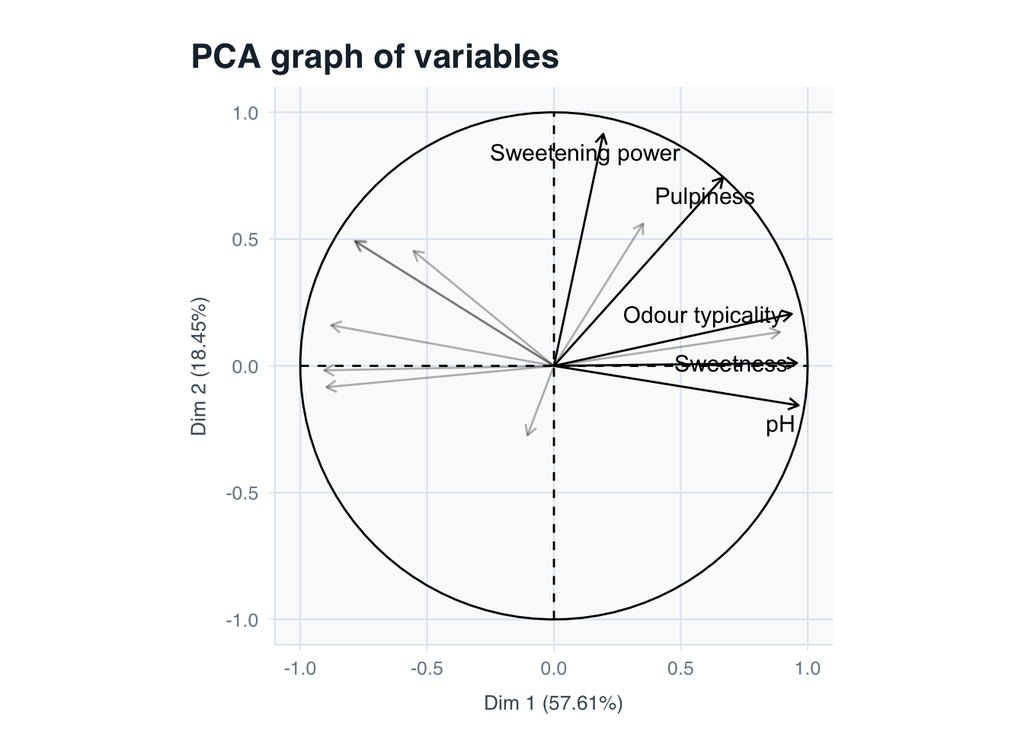

```r
# Variables que más contribuyen
plot(res, choix = "var", select = "contrib 5")
```

### 5.7.4 Gráfico combinado (orange)

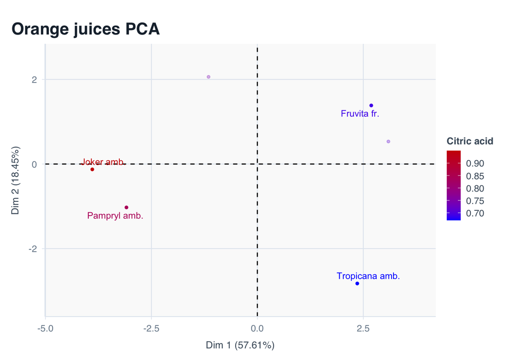

```r
plot(
  res,
  cex        = 0.8,
  habillage  = 13,
  select     = "cos2 0.7",
  title      = "Orange juices PCA",
  cex.main   = 1.1,
  cex.axis   = 0.9,
  shadow     = TRUE,
  auto       = "y"
)
```

# 6 Cierre del laboratorio

En este laboratorio:

- Aplicaste **PCA** a dos conjuntos de datos reales (Decathlon y jugos de naranja).
- Revisaste la idoneidad del análisis mediante **Bartlett** y **KMO**.
- Interpretaste **valores propios**, varianza explicada y elegiste cuántas componentes retener.
- Analizaste:
  - Cargas de las variables (coordenadas y cos2).
  - Contribuciones de variables e individuos.
  - Gráficos de individuos por grupos, con **elipses de confianza**.
  - Variables e individuos “más importantes” (por contribución o calidad de representación).

Estos elementos son fundamentales para:

- Reducir dimensionalidad en bases con muchas variables.
- Explorar estructuras latentes antes de aplicar otros métodos (clustering, regresión, etc.).
- Construir indicadores sintéticos a partir de múltiples variables observadas.